# IE6400 Foundations for Data Analytics Engineering

# Fall 2023

### Module 2: Probability

#### - FULL READING -

Uncertainty involves making decisions with incomplete information, and this is the way we generally operate in the world. Handling uncertainty is typically described using everyday words like chance, luck, and risk. Probability is a field of mathematics that gives us the language and tools to quantify the uncertainty of events and reason in a principled manner.

In probability theory, an **experiment** or **trial** is any procedure that can be infinitely repeated and has a well-defined set of possible outcomes, known as the sample space

### Sample Space

• The sample space Ω is the set of possible outcomes of an experiment. Points ω in Ω are called sample outcomes, realizations, or elements. Subsets of Ω are called Events.

• *Example*. Our experiment is tossing a coin twice. If we repeat this procedure 4 times then Ω = {HH,HT, TH, TT} is our sample space. The event that the first toss is heads is A = {HH,HT}

### Mutually Exclusive Events

Mutually exclusive events are those events that do not occur at the same time.

• We say that events A1 and A2 are disjoint (mutually exclusive) if Ai ∩ Aj = {}

• Example: first flip being heads and first flip being tails, since outcome of a flip of a coin cannot be heads and tails at the same time

### Multiplication Rule

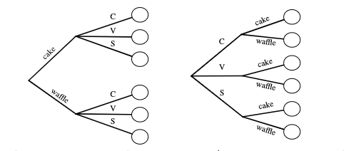

Let’s say we have a compound experiment (an experiment with multiple components). If the 1st component has n1 possible outcomes, the 2nd component has n2 possible outcomes, . . . , and the rth component has nr possible outcomes, then overall there are n1 x n2 x . . . x nr possibilities for the whole experiment. Graph above are also known as tree diagrams.

*Example*

In the graph above (left) you can see 2 components Cake and Waffle, and both of them have 3 possible outcomes C, V, S. The number of possibilities for this experiment is 2 x 3 = 6.

On the right graph there are 3 components C,V,S and 2 outcomes for each. So number of possibilities for this experiment is 2 x 3 = 6.

### Sampling Table

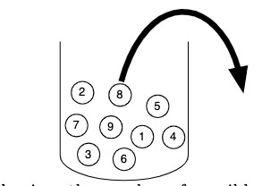

The sampling table gives the number of possible samples of size k out of a population of size n, under various assumptions about how the sample is collected.

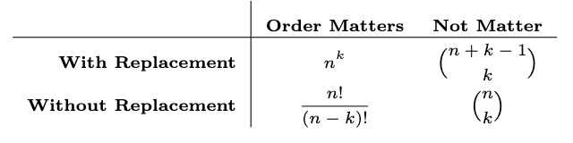

### Definition of Probability

Probability is a measure that quantifies the likelihood that an event will occur.

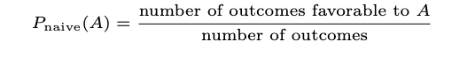

The assigned probability is a fractional value and is always in the range between 0 and 1, where 0 indicates no probability and 1 represents full probability. Together, the probability of all possible events sums to the probability value one. If all possible occurrences are equally likely, the probability of their occurrence is 1 divided by the total possible occurrences or trials.

### Unions, Intersections, and Complements

A union refers to an area that is said to be belonging to one or both of two events. In contrast, an intersection is an area that is said to be belonging to both of those two events.

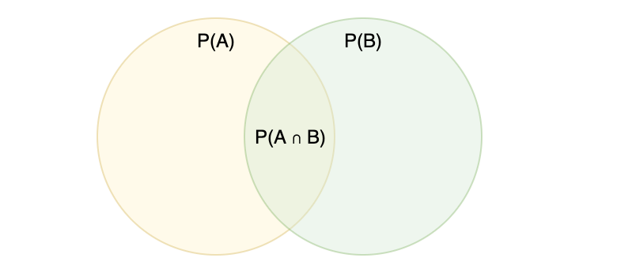

Small c next to event indicates a complement of an event. complement of an event is all the other outcomes (not the ones we want). And together the event and its complement make all possible outcomes.

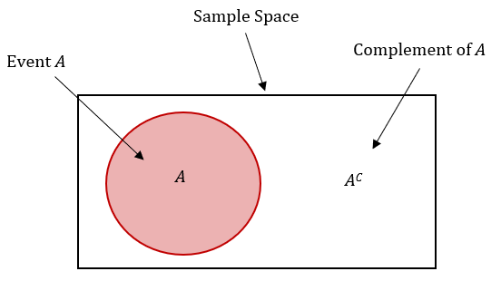

De Morgan’s Laws A useful identity that can make calculating probabilities of unions easier by relating them to intersections, and vice versa. Analogous results hold with more than two sets.

### Thinking Conditionally

#### Independent Events

A and B are independent if knowing whether A occurred gives no information about whether B occurred. More formally, A and B (which have nonzero probability) are independent if and only if one of the following equivalent statements holds:

P (A ∩ B) = P (A)P (B)

P (A|B) = P (A)

p (B|A) = P (B)

**Conditional Independence**: A and B are conditionally independent given C if P (A ∩ B|C) = P (A|C)P (B|C). Conditional independence does not imply independence, and independence does not imply conditional independence.

**Dependent events** are those which depend upon what happened before. If A and B are dependent: P (A ∩ B) = P(A) * P(B|A)

For **mutually exclusive** events: P (A or B) = P(A) + P(B)

For **mutually inclusive** events: P (A or B) = P(A) + P(B) - P (A and B)

### Probability of an Intersection or Union

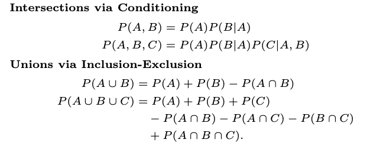

#### Exercise 1 Probability of Drawing Two Consecutive Red Cards from Two Decks

**Problem Statement:**  
Suppose you have two decks of playing cards, each containing 52 cards (standard decks). What is the probability of drawing two cards consecutively (without replacement) from the two decks and both cards being red (hearts or diamonds)?

**Solution:**

1. **First Card is Red:**
   - There are 2 decks, so there are (2 $\times$ 52 = 104) total cards.
   - Each deck has 26 red cards (13 hearts and 13 diamonds), so in 2 decks, there are (2 $\times$ 26 = 52) red cards.
   - The probability that the first card drawn is red is: [ $P(\text{1st card is red}) = \frac{\text{Number of red cards}}{\text{Total number of cards}} = \frac{52}{104} = \frac{1}{2}$ ]
2. **Second Card is Red (given that the first card was red):**
   - After drawing the first red card, there are (104 - 1 = 103) cards left.
   - And there are (52 - 1 = 51) red cards left.
   - The probability that the second card drawn is red, given that the first card was red, is: [ $P(\text{2nd card is red | 1st card was red}) = \frac{51}{103}$ ]
3. **Both Cards are Red:**
   - The probability that both cards drawn consecutively are red is the product of the two probabilities: [ $P(\text{Both cards are red}) = P(\text{1st card is red}) \times P(\text{2nd card is red | 1st card was red}) = \frac{1}{2} \times \frac{51}{103}$ ]

**Result:**  
The probability that both cards drawn consecutively from the two decks are red is approximately ($0.2476$) or ($24.76\%$).

#### Exercise 2 Probability of Drawing a Spade and then a Heart from a Standard Deck

**Problem Statement:**  
Suppose you have a standard deck of 52 playing cards. What is the probability of drawing a spade (one card) and then drawing a heart (without replacement)?

**Solution:**

1. **First Card is a Spade:**
   - In a standard deck of 52 cards, there are 13 spades.
   - The probability that the first card drawn is a spade is: [ $P(\text{1st card is a spade}) = \frac{\text{Number of spades}}{\text{Total number of cards}} = \frac{13}{52} = \frac{1}{4}$ ]
2. **Second Card is a Heart (given that the first card was a spade):**
   - After drawing the first spade, there are (52 - 1 = 51) cards left.
   - There are 13 hearts in the deck.
   - The probability that the second card drawn is a heart, given that the first card was a spade, is:

     $P(\text{2nd card is a heart | 1st card was a spade}) = \frac{13}{51}$
1. **Drawing a Spade and then a Heart:**
   - The probability that the first card drawn is a spade and the second card is a heart is:

     $P(\text{1st card is a spade and 2nd card is a heart}) = \frac{1}{4} \times \frac{13}{51} \approx 0.0637 \text{ or } 6.37\%$

#### Exercise 3 Probability of Drawing At Least One Blue Marble

**Problem Statement:**  
A jar contains 30 marbles: 10 red, 15 blue, and 5 green. If you draw two marbles from the jar without replacement, what is the probability that at least one of them is blue?

**Solution:**

1. **Probability that Neither Marble is Blue:**
   - The probability that the first marble drawn is not blue (i.e., red or green) is:

     $P(\text{1st marble is not blue}) = \frac{10 + 5}{30} = \frac{1}{2}$
- Given that the first marble drawn is not blue, the probability that the second marble drawn is also not blue is:

  $P(\text{2nd marble is not blue | 1st marble was not blue}) = \frac{14}{29}$
- The combined probability that neither of the two marbles drawn is blue is:

  $P(\text{Both marbles are not blue}) = \frac{1}{2} \times \frac{14}{29} = \frac{7}{29}$
1. **Probability that At Least One Marble is Blue:**
   - The probability that at least one of the two marbles drawn is blue is:

     $P(\text{At least one marble is blue}) = 1 - \frac{7}{29} = \frac{22}{29}$

#### Exercise 4

Two dice are rolled. What is the probability that the sum of the numbers on the dice is either 7 or 11?

**Answer 4:** To find the probability of the union (7 or 11), we calculate the individual probabilities first.

- Probability of getting 7: There are 6 ways to get a sum of 7 (1+6, 2+5, 3+4, 4+3, 5+2, 6+1), and there are 36 possible outcomes in total. So, P(7) = 6/36.
- Probability of getting 11: There are 2 ways to get a sum of 11 (5+6, 6+5), so P(11) = 2/36.
- Now, we calculate the probability of the union: P(7 or 11) = P(7) + P(11) = (6/36) + (2/36) = 8/36 = 2/9.

#### Exercise 5

A deck of cards contains 52 cards. What is the probability of drawing a red card (hearts or diamonds) and then drawing a king from a standard deck without replacement?

**Answer 5:** First, let's find the probability of drawing a red card:

- There are 26 red cards (13 hearts and 13 diamonds) out of 52 cards, so P(red card) = 26/52 = 1/2.

  Next, given that you've already drawn a red card, you have 51 cards left in the deck (one card has been removed).

  Now, let's find the probability of drawing a king:
- There are 4 kings in the deck (one in each suit), so P(king) = 4/51.

  To find the overall probability of both events happening (red card and then a king), you multiply the probabilities:
- P(red card and king) = P(red card) *P(king) = (1/2)* (4/51) = 2/51.

#### Exercise 6

Suppose you have a fair six-sided die. What is the probability of rolling a 4 on the first roll and then rolling a 6 on the second roll?

**Answer 6:** To solve this problem, we can use the concept of independent events. When rolling a die, the outcome of one roll does not affect the outcome of another roll.

- Probability of rolling a 4 on the first roll: P(4) = 1/6
- Probability of rolling a 6 on the second roll: P(6) = 1/6

Since the rolls are independent, we can multiply the probabilities: P (4 and 6) = P(4) *P(6) = 1/6* 1/6 = 1/36

So, the probability of rolling a 4 on the first roll and then rolling a 6 on the second roll is 1/36.

#### Exercise 7

In a deck of playing cards, what is the probability of drawing either a red card (hearts or diamonds) or a face card (king, queen, or jack)?:

Probability of drawing a red card: P(red) = 26/52 = 1/2 Probability of drawing a face card: P(face) = 12/52 = 3/13

Since the events are mutually exclusive, we can add their probabilities: P(red + face) P(red) + p (face) = 1/2 + 3/13 = 19/26

So, the probability of drawing either a red card or a face card from a deck of playing cards is 19/26

### Permutation and Combination:

**Permutation** and **combination** are the ways to select certian objects from a group of objects to form subsets with or without replacement. It defines the various ways to arrange a certain group of data. When we select the data or objects from a certain group, it is said to be **permutations**, whereas the order in which they are represented is called **combination**.

A **permutation** is the choice of r things from a set of n things without replacement and where the order matters.

A **combination** is the choice of r things from a set of n things without replacement and where order does not matter.

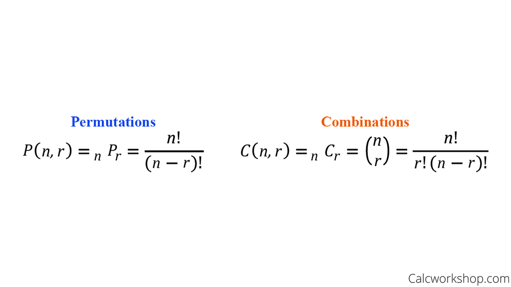

#### Exercise 8

You have 5 different books, and you want to arrange them on a shelf. How many different ways can you arrange the books?

**Answer 8:** The number of different ways you can arrange these 5 books is calculated using the concept of permutations. The number of permutations of n distinct items taken all at a time is given by n!. Here, n represents the number of items, and "!" denotes the factorial of a number.

In this case, you have 5 different books, so the number of ways to arrange them on the shelf is:

5! = 5 x 4 x 3 x 2 x 1 = 120

So, there are 120 different ways to arrange the 5 different books on the shelf.

#### Exercise 9

A committee of 3 students is to be chosen from a group of 10 students. How many different committees can be formed?

**Answer 9:** To find the number of different committees that can be formed by choosing 3 students from a group of 10 students, you can use the combination formula. In this case, you want to choose 3 students from a group of 10, so n = 10 and k = 3.

C(10, 3) = 10! / (3! * (10 - 3)!)

Now, calculate the factorials and simplify:

C(10, 3) = 10! / (3! * 7!)

10! = 10 x 9 x 8 x 7! (10 factorial) 3! = 3 x 2 x 1 (3 factorial)

C(10, 3) = (10 x 9 x 8 x 7!) / (3 x 2 x 1 x 7!)

Now, you can cancel out the common factor of 7!:

C(10, 3) = (10 x 9 x 8) / (3 x 2 x 1)

C(10, 3) = (720) / (6)

C(10, 3) = 120

So, there are 120 different committees that can be formed by choosing 3 students from a group of 10 students.

#### Exercise 10

You have 6 different flavors of ice cream, and you want to create a 3-scoop ice cream cone. How many different combinations of ice cream cones can you create if the order of scoops matters (permutations) and if it doesn't matter (combinations)?

**Answer 10:**

1.Permutations (Order Matters): When order matters, it's a permutation. In this case, you want to arrange 3 scoops out of 6 flavors:

P(6, 3) = 6! / (6 - 3)!

P(6, 3) = 6! / (6 - 3)! P(6, 3) = 6! / 3! P(6, 3) = (6 x 5 x 4 x 3!) / 3! P(6, 3) = (6 x 5 x 4)

P(6, 3) = 120

So, there are 120 different permutations of 3-scoop ice cream cones when the order of scoops matters.

2.Combinations (Order Doesn't Matter): When order doesn't matter, it's a combination. In this case, you want to choose 3 scoops out of 6 flavors:

C(6, 3) = 6! / (3! * (6 - 3)!)

C(6, 3) = 6! / (3! * 3!) C(6, 3) = (6 x 5 x 4) / (3 x 2 x 1)

C(6, 3) = 20

So, there are 20 different combinations of 3-scoop ice cream cones when the order of scoops doesn't matter.

#### Exercise 11

A basketball team consists of 12 players, and only 5 can play at a time. How many different starting lineups can the coach choose?

**Answer 11:** To find the number of different starting lineups the coach can choose from a basketball team of 12 players where only 5 can play at a time, you can use the combination formula.

In this case, you want to choose 5 players out of 12:

C(12, 5) = 12! / (5! * (12 - 5)!)

C(12, 5) = 12! / (5! * 7!)

Now, calculate the factorials and simplify:

C(12, 5) = (12 x 11 x 10 x 9 x 8) / (5 x 4 x 3 x 2 x 1)

C(12, 5) = (12 x 11 x 10 x 9 x 8) / (5 x 4 x 3 x 2 x 1)

C(12, 5) = 792

So, the coach can choose from 792 different starting lineups for the basketball team.

#### Exercise 12

A restaurant offers a menu with 10 appetizers, 15 main courses, and 8 desserts. How many different 3-course meals (1 appetizer, 1 main course, and 1 dessert) can a customer choose?

**Answer 12:** To find the number of different 3-course meals (1 appetizer, 1 main course, and 1 dessert) a customer can choose from a menu with 10 appetizers, 15 main courses, and 8 desserts, you can use the multiplication principle.

In this case, you have:

10 ways to choose an appetizer (from 10 options). 15 ways to choose a main course (from 15 options). 8 ways to choose a dessert (from 8 options). To find the total number of different 3-course meals, simply multiply the number of choices for each course:

Total number of different 3-course meals = (Number of appetizers) *(Number of main courses)* (Number of desserts) Total number of different 3-course meals = 10 *15* 8

Total number of different 3-course meals = 1,200

So, a customer can choose from 1,200 different 3-course meals on the menu.

#### Exercise 13

Create a function named cointoss(n). Where n indicates the number of times to toss a coin and 1 <= n <= 3

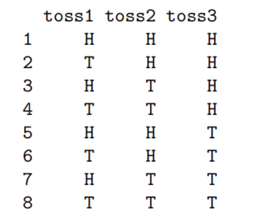

#### Exercise 14

Create a function named rolldie(n). Where n indicates the number of times to roll a die and 1 <= n <= 3

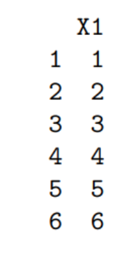

#### Exercise 15

Create a probspace(experiment, n) function where the experiment can be a cointoss or a rolldie. If the option selected is cointoss, then generate a sample space and the probability for the coin toss. If the option selected is rolldie then then generate a sample space and the probability for the same

### Probability Distributions

#### Discrete Random Variable:

A discrete random variable is a variable that can take on a countable number of distinct values. These values are often integers or whole numbers.

1. The number of heads obtained when flipping a coin multiple times (can only be 0, 1, 2, ...).
2. The number of customers entering a store in an hour (can only be non-negative integers).
3. The outcome of rolling a six-sided die (1, 2, 3, 4, 5, or 6).

**Probability Distribution:** For a discrete random variable, you can specify its probability distribution using a probability mass function (PMF). The PMF assigns probabilities to each possible value of the random variable.

Examples of Discrete Probability Distributions:

1. Bernoulli distribution.
2. Binomial distribution.
3. Poisson distribution.

**Sampling:** Discrete random variables are often encountered in scenarios where you count or tally something, such as counting occurrences or events.

#### **Continuous Random Variable:**

A continuous random variable is a variable that can take on an uncountably infinite number of values within a given range. These values are often real numbers.

- The height of individuals in a population (can be any real number within a range).
- The time it takes for a computer to complete a task (can be any positive real number).

**Probability Distribution:** For a continuous random variable, you specify its probability distribution using a probability density function (PDF). The PDF provides the relative likelihood of the variable taking on a specific value within a given range.

**Probability Distributions:**

1. Normal distribution.
2. Uniform distribution.
3. Exponential distribution.

**Sampling:** Continuous random variables are often encountered in scenarios where you measure quantities that can take on a wide range of values with precision.

### Random Variables and Probability Functions

#### Probability Mass Function (PMF):

1. A PMF is used for discrete random variables, which take on specific, countable values.
2. It assigns probabilities to each possible value of the discrete random variable.
3. The PMF satisfies two key properties: non-negativity (probabilities are non-negative) and the sum of probabilities is equal to 1.

#### Probability Density Function (PDF):

- A PDF is used for continuous random variables, which can take on a continuous range of values.
- It provides the probability that the random variable falls within a specific interval.
- The area under the PDF curve over an interval represents the probability of the variable falling within that interval.

#### Cumulative Distribution Function (CDF):

- A CDF, denoted as F(x), gives the probability that a random variable X takes on a value less than or equal to x.
- It is defined for both discrete and continuous random variables.

#### Exercise 16

Suppose the height (in centimeters) of adult males in a population follows a normal distribution with a mean (μ) of 175 cm and a standard deviation (σ) of 7 cm. Calculate the probability that a randomly selected adult male is between 165 cm and 185 cm tall.

#### Answer 16:

To calculate this probability, you can use the PDF of the normal distribution. The probability of a random variable X falling between two values a and b is given by the area under the PDF curve between a and b.

In this case, you want to find P(165 ≤ X ≤ 185), which represents the probability that a male's height is between 165 cm and 185 cm.

Using the standard normal distribution (z-score) and a Z-table or calculator, you can find the probabilities:

Z-score for 165 cm: 165-175/7 = -1.43 Z-score for 185 cm: 185-175/7 = 1.43

#### Exercise 17 Probability Density Function (PDF) for Adult Heights

**Problem Statement:**  
Given a dataset of adult heights, calculate the probability density function (PDF) for the height of adults within a certain range.

**Solution:**

1. **Data Collection:**
   - Obtain a dataset that represents the heights of a large sample of adults. This will ensure that the dataset is a good representation of the general population.
2. **Data Cleaning:**
   - Before analysis, ensure that the dataset is clean. This involves checking for missing values, outliers, or any other inconsistencies in the data. Handle these appropriately, either by imputation or removal.
3. **Histogram Creation:**
   - Construct a histogram to visualize the distribution of heights. The x-axis will represent height intervals (bins), and the y-axis will represent the frequency of data points within each bin.
4. **Calculate PDF:**
   - The PDF provides a normalized view of the histogram. It represents the likelihood of a value falling within a particular range.
   - To calculate the PDF for each bin:

     $f(x) = \frac{\text{Number of data points in bin}}{\text{Total number of data points} \times \text{Width of bin}}$
   - The integral (or area) under the PDF curve across all possible values will sum up to 1.
5. **Visualization:**
   - Plot the PDF to get a visual representation of the distribution of heights. The x-axis will have height values, while the y-axis will depict the probability density.
6. **Analysis:**
   - The PDF can be used to determine the probability of a randomly chosen adult having a height within a specific range. The area under the curve of the PDF for that range gives the probability.

**Note:**  
To get specific probabilities for certain height ranges, integrate (find the area) under the PDF curve for that range.

#### Exercise 18 Probability of Height Between 165 cm and 185 cm

**Problem Statement:**  
Suppose the height (in centimeters) of adult males in a population follows a normal distribution with a mean (μ) of 175 cm and a standard deviation (σ) of 7 cm. Calculate the probability that a randomly selected adult male is between 165 cm and 185 cm tall.

**Solution:**

1. **Z-score Calculation:**
   - The Z-score for (X = 165) is:

     $Z_1 = \frac{165 - 175}{7} = -1.4286$
   - The Z-score for (X = 185) is:

     $Z_2 = \frac{185 - 175}{7} = 1.4286$
1. **Probability Calculation:**
   - Using the standard normal distribution:

     $P(Z \leq -1.4286) \approx 0.0764$

     $P(Z \leq 1.4286) \approx 0.9236$
   - The probability that a randomly selected adult male is between 165 cm and 185 cm tall is:

     $P(165 \leq X \leq 185) = 0.9236 - 0.0764 = 0.8472 \text{ or } 84.72\%$

### Bayes' Theorem

Bayes' Theorem, often referred to as Bayes' Rule, is a fundamental concept in probability theory and statistics. It provides a way to update the probability for a hypothesis (an event or proposition) based on new evidence or information.

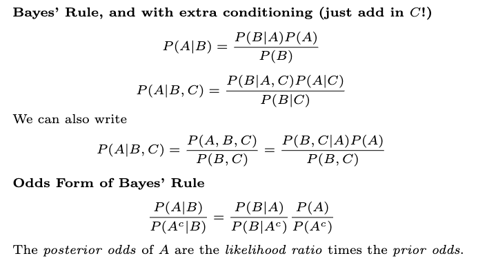

Bayes' Theorem states that the probability of event A occurring, given that event B has occurred, is equal to the probability of event B occurring given that event A has occurred, multiplied by the prior probability of event A, divided by the prior probability of event B.

Bayes' Theorem is particularly useful in situations where you have prior knowledge or beliefs about an event and you want to update those beliefs based on new evidence.

#### Exercise 19 Probability of Having the Disease Given a Positive Test Result

**Problem Statement:**  
A medical test is used to diagnose a rare disease. The test is 98% accurate when the disease is present and correctly identifies a healthy person 95% of the time. The disease occurs in 1% of the population. If a person tests positive, what is the probability that they actually have the disease?

**Solution:**  
Using Bayes' Theorem:

$P(D|T) = \frac{P(T|D) \times P(D)}{P(T)}$

Where:

- $P(T|D)$ = 0.98 (Probability of testing positive given that one has the disease)
- $P(D)$ = 0.01 (Probability of having the disease)
- $P(T|D^c)$ = 0.05 (Probability of testing positive given that one does not have the disease)
- $P(D^c)$ = 0.99 (Probability of not having the disease)

Using the law of total probability: $P(T) = 0.0098 + 0.0495 = 0.0593$

Finally, plugging in the values: $P(D|T) \approx \frac{0.98 \times 0.01}{0.0593} = 0.1652$

**Result:**  
The probability that a person who tests positive actually has the disease is approximately ( $16.52\%$ ).

#### Exercise 20 Probability of a Defective Bulb Coming from Machine A

**Problem Statement:**  
A factory produces light bulbs using two machines (Machine A and Machine B). Machine A produces 60% of the bulbs, while Machine B produces 40%. Machine A's bulbs have a defect rate of 5%, while Machine B's bulbs have a defect rate of 3%. If a randomly selected bulb is defective, what is the probability that it came from Machine A?

**Solution:**  
Using Bayes' Theorem:

$P(A|D) = \frac{P(D|A) \times P(A)}{P(D)}$

Where:

- $P(D|A)$ = 0.05 (Probability that a bulb is defective given that it was produced by Machine A)
- $P(A)$ = 0.60 (Probability that a bulb was produced by Machine A)
- $P(D|B)$ = 0.03 (Probability that a bulb is defective given that it was produced by Machine B)
- $P(B)$ = 0.40 (Probability that a bulb was produced by Machine B)

Using the law of total probability: $P(D) = 0.05 \times 0.60 + 0.03 \times 0.40 = 0.042$

Finally, plugging in the values: $P(A|D) \approx \frac{0.05 \times 0.60}{0.042} = 0.7143$

**Result:**  
The probability that a defective bulb came from Machine A is approximately ( $71.43\%$ ).

Revised Date: October 8, 2023